# **Remaining Useful Life Prediction Using Jet Engine Sensor Time-Series Data and Machine Learning**

#### Author: Luis Rito Filipe

#### November, 2025

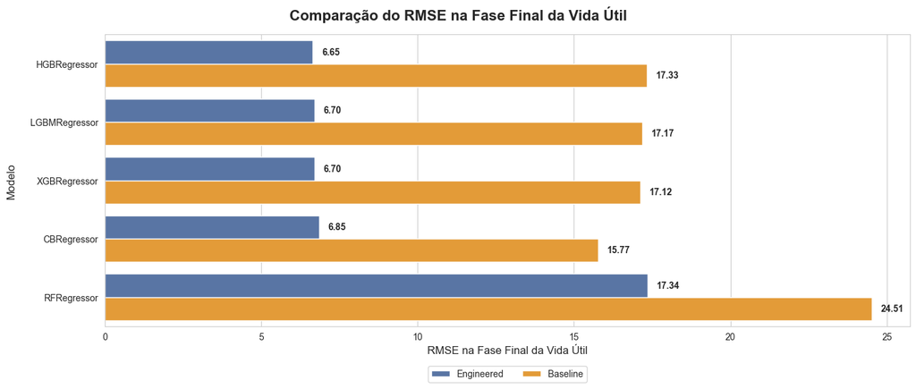

# Summary

Remaining Useful Life (RUL) prediction is an important task in predictive maintenance, aiming to estimate the operational time remaining before equipment failure. Accurate RUL estimation enables more efficient maintenance scheduling, reduces operational costs, and improves system reliability.

To capture temporal degradation behavior, the data was transformed into sequential intervals using a sliding sequence approach. Several preprocessing and feature engineering techniques were applied to represent changes in engine condition over time, which contributed to a significant error reduction of RUL estimation.

Multiple regression models were evaluated for the RUL prediction task, including Random Forest Regressor, XGBoost Regressor, LightGBM Regressor, CatBoost Regressor, and Histogram-based Gradient Boosting Regressor. Model performance was assessed using Root Mean Squared Error (RMSE) and Mean Absolute Error (MAE), as well as stage-wise evaluation across early, mid, and late engine life.

The results show that prediction performance strongly depends on the degradation stage. Early-stage predictions present higher error due to weak and unstable degradation signatures, while mid- and late-stage predictions achieve significantly better accuracy as degradation patterns become more detectable in the sensor data. Gradient boosting methods achieved the best overall performance.

The study demonstrates that Remaining Useful Life prediction is not uniformly learnable across the entire engine lifecycle using regression models. Instead, predictive performance is closely related to the observability of degradation signals in the sensor measurements. Overall, the developed pipeline provides an effective machine learning framework for RUL estimation and highlights the challenges associated with early-stage prognostics in complex industrial systems.

# About The Study

This study investigates the prediction of jet engine Remaining Useful Life (RUL), using simulated time-series data from multiple sensors and machine learning techniques. To achieve this, widely used Python libraries for data analysis and machine learning are employed, including tools for data manipulation, visualization, and predictive modeling. The study follows a structured approach, beginning with data preprocessing, followed by exploratory data analysis (EDA) and feature engineering, and concluding with model training and results comparison.

# About The Dataset

The dataset consists of jet engine operational cycles and sensor measurements collected throughout a simulated degradation process provided by National Aeronautics and Space Administration (NASA).

Dataset link: https://data.nasa.gov/dataset/cmapss-jet-engine-simulated-data

# Methodology

- Data Wrangling and Preprocessing
- Exploratory Data Analysis and Feature Evaluation
- Model Training
- Results Comparison
- Discussion
- Conclusion

# Data Wrangling and Preprocessing

The dataset consists of training, testing, and Remaining Useful Life (RUL) files. In this study, only the train_FD001 subset was used. This subset contains operational data from 100 jet engines operating under a single fault condition and a single operating condition.

Each engine was monitored over a varying number of operational cycles until failure. The dataset does not include column labels directly; therefore, variable names provided in the accompanying metadata file were assigned. The dataset structure is organized as follows:

- engine_id: unique identifier for each engine
- cycle: operational cycle number
- setting_1 to setting_3: operational setting variables
- sensor_1 to sensor_21: sensor measurements collected during engine operation

The target variable, Remaining Useful Life (RUL), was computed by subtracting the current cycle from the maximum cycle observed for each engine.

Summary statistics of the dataset variables are presented below.

```
<class 'pandas.core.frame.DataFrame'>
RangeIndex: 20631 entries, 0 to 20630
Columns: 26 entries, engine_id to sensor_21
dtypes: float64(22), int64(4)
memory usage: 4.1 MB
```

|  | engine_id | cycle | setting_1 | setting_2 | setting_3 | sensor_1 | sensor_2 | sensor_3 | sensor_4 | sensor_5 | sensor_6 | sensor_7 | sensor_8 | sensor_9 | sensor_10 | sensor_11 | sensor_12 | sensor_13 | sensor_14 | sensor_15 | sensor_16 | sensor_17 | sensor_18 | sensor_19 | sensor_20 | sensor_21 |
| --- | --- | --- | --- | --- | --- | --- | --- | --- | --- | --- | --- | --- | --- | --- | --- | --- | --- | --- | --- | --- | --- | --- | --- | --- | --- | --- |
| count | 20631.000000 | 20631.000000 | 20631.000000 | 20631.000000 | 20631.0 | 20631.00 | 20631.000000 | 20631.000000 | 20631.000000 | 2.063100e+04 | 20631.000000 | 20631.000000 | 20631.000000 | 20631.000000 | 20631.0 | 20631.000000 | 20631.000000 | 20631.000000 | 20631.000000 | 20631.000000 | 2.063100e+04 | 20631.000000 | 20631.0 | 20631.0 | 20631.000000 | 20631.000000 |
| mean | 51.506568 | 108.807862 | -0.000009 | 0.000002 | 100.0 | 518.67 | 642.680934 | 1590.523119 | 1408.933782 | 1.462000e+01 | 21.609803 | 553.367711 | 2388.096652 | 9065.242941 | 1.3 | 47.541168 | 521.413470 | 2388.096152 | 8143.752722 | 8.442146 | 3.000000e-02 | 393.210654 | 2388.0 | 100.0 | 38.816271 | 23.289705 |
| std | 29.227633 | 68.880990 | 0.002187 | 0.000293 | 0.0 | 0.00 | 0.500053 | 6.131150 | 9.000605 | 5.329200e-15 | 0.001389 | 0.885092 | 0.070985 | 22.082880 | 0.0 | 0.267087 | 0.737553 | 0.071919 | 19.076176 | 0.037505 | 3.469531e-18 | 1.548763 | 0.0 | 0.0 | 0.180746 | 0.108251 |
| min | 1.000000 | 1.000000 | -0.008700 | -0.000600 | 100.0 | 518.67 | 641.210000 | 1571.040000 | 1382.250000 | 1.462000e+01 | 21.600000 | 549.850000 | 2387.900000 | 9021.730000 | 1.3 | 46.850000 | 518.690000 | 2387.880000 | 8099.940000 | 8.324900 | 3.000000e-02 | 388.000000 | 2388.0 | 100.0 | 38.140000 | 22.894200 |
| 25% | 26.000000 | 52.000000 | -0.001500 | -0.000200 | 100.0 | 518.67 | 642.325000 | 1586.260000 | 1402.360000 | 1.462000e+01 | 21.610000 | 552.810000 | 2388.050000 | 9053.100000 | 1.3 | 47.350000 | 520.960000 | 2388.040000 | 8133.245000 | 8.414900 | 3.000000e-02 | 392.000000 | 2388.0 | 100.0 | 38.700000 | 23.221800 |
| 50% | 52.000000 | 104.000000 | 0.000000 | 0.000000 | 100.0 | 518.67 | 642.640000 | 1590.100000 | 1408.040000 | 1.462000e+01 | 21.610000 | 553.440000 | 2388.090000 | 9060.660000 | 1.3 | 47.510000 | 521.480000 | 2388.090000 | 8140.540000 | 8.438900 | 3.000000e-02 | 393.000000 | 2388.0 | 100.0 | 38.830000 | 23.297900 |
| 75% | 77.000000 | 156.000000 | 0.001500 | 0.000300 | 100.0 | 518.67 | 643.000000 | 1594.380000 | 1414.555000 | 1.462000e+01 | 21.610000 | 554.010000 | 2388.140000 | 9069.420000 | 1.3 | 47.700000 | 521.950000 | 2388.140000 | 8148.310000 | 8.465600 | 3.000000e-02 | 394.000000 | 2388.0 | 100.0 | 38.950000 | 23.366800 |
| max | 100.000000 | 362.000000 | 0.008700 | 0.000600 | 100.0 | 518.67 | 644.530000 | 1616.910000 | 1441.490000 | 1.462000e+01 | 21.610000 | 556.060000 | 2388.560000 | 9244.590000 | 1.3 | 48.530000 | 523.380000 | 2388.560000 | 8293.720000 | 8.584800 | 3.000000e-02 | 400.000000 | 2388.0 | 100.0 | 39.430000 | 23.618400 |

Missing values were inspected and no missing observations were found in the dataset. Based on the summary statistics, some features presented only a single unique value across all observations. Such features exhibit no variance and therefore provide no discriminative or predictive information for machine learning tasks, including clustering, regression, and anomaly detection. Consequently, these features were removed from the dataset.

To support Remaining Useful Life (RUL) estimation, the maximum operational cycle reached by each engine (max_cycle) was first computed by grouping the dataset by engine_id and extracting the maximum value of the cycle variable. This intermediate quantity was then used to derive the target variable, Remaining Useful Life (RUL), defined as the difference between max_cycle and the current cycle for each observation. After target construction, max_cycle was removed.

```
Features removed: ['setting_3', 'sensor_1', 'sensor_5', 'sensor_10', 'sensor_16', 'sensor_18', 'sensor_19']
```

# Exploratory Data Analysis and Feature Evaluation

Below is a chart of a selected sensor from four engines. Each engine exhibits different lifetime and signal amplitude. Several sensors show a common structural pattern: an initial phase of relatively stable oscillation within a narrow range, followed by a later phase where the signal begins to deviate from its baseline behavior, often showing increased variability or directional drift as the engine approaches failure.

This suggests a two-regime behavior in certain sensors: an early operational steady-state regime characterized by bounded oscillations, and a late-stage degradation regime where statistical properties of the signal shift away from baseline behavior. The transition point varies across engines and is associated with remaining useful life.

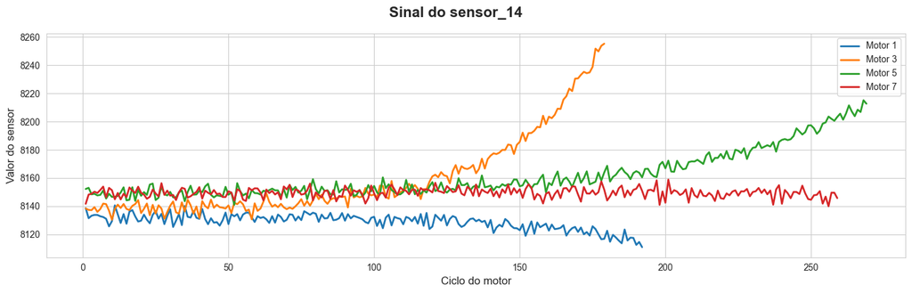

Sensor_6 exhibits a highly sparse and discontinuous distribution, characterized by long constant regimes punctuated by rare binary transitions. Such behavior is not aligned with the continuous degradation assumption underlying the majority of sensor features. This mismatch in signal structure may bias feature importance estimates and degrade model generalization, particularly for regression-based models.

In contrast, several other sensors exhibit a more consistent degradation structure, characterized by an initial operational stage in which the signal oscillates within a narrow range, followed by a degradation phase where the signal begins to drift away from its healthy operating region and progressively develops a clearer and steeper trend as the engine approaches failure.

Below is a plot grid illustrating a selection of sensor and operational setting signals from a representative engine, together with some statistical indicators. These visualizations demonstrate the progressive deviation from baseline operating conditions and the temporal degradation patterns captured throughout the engine lifecycle. The red envelopes represent a visualization aid constructed as the mean ± one standard deviation of the sensor signal. These envelopes were further modified by freezing their value from the most stable cycle identified in the early operational phase for each sensor. Although initially designed as a degradation thresholding mechanism to enhance linearity in subsequent feature transformations, this approach did not yield improvements in predictive performance. Nevertheless, the visualization is retained as it provides an intuitive interpretation of deviation from baseline operating conditions and supports understanding of the degradation process.

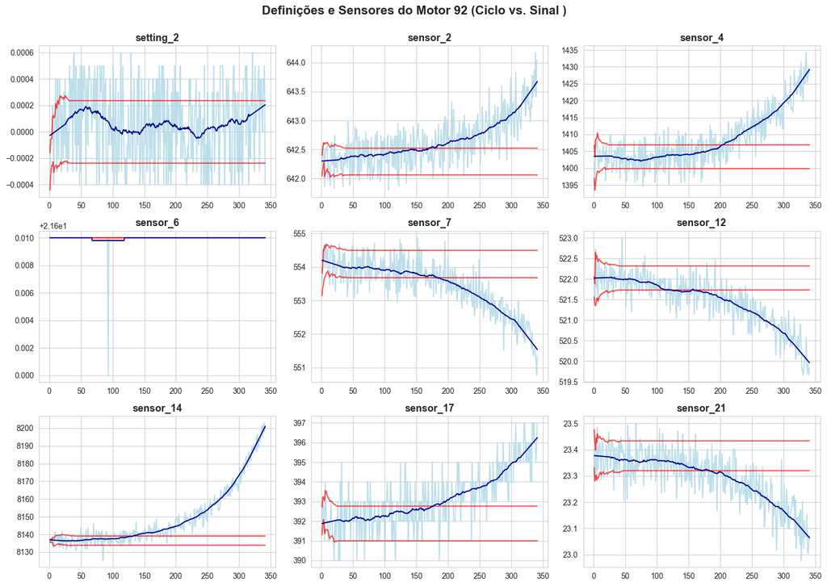

Additional features were engineered to capture both linear and non-linear degradation behavior, providing the models with more informative representations than the original sensor measurements alone and improving predictive performance. These engineered features were applied to all sensors used at this stage.

After evaluating multiple configurations of complex engineered features, no consistent improvement in predictive performance was observed. In contrast, signal transformation based on Savitzky–Golay smoothing provided the best late-stage accuracy, suggesting that preserving the underlying degradation trajectory while reducing high-frequency noise was more effective than introducing highly transformed statistical representations.

Therefore, a Savitzky–Golay (savgol) filter with a 51-period window was introduced to provide a smoother representation of the underlying sensor dynamics while maintaining lower lag compared to a simple moving average or a smoothed distance score relative to a baseline.

Feature correlation analysis was performed to identify highly correlated pairs of independent variables, enabling the removal of redundant features and improving model robustness.

A correlation threshold of 0.95 was adopted, such that when two independent variables exhibited an absolute correlation coefficient equal to or greater than this value, the feature with the lower mutual information score relative to the target variable was removed. This approach reduces feature redundancy while preserving the variables with the highest predictive relevance, mitigating multicollinearity effects and decreasing the risk of overfitting.

Sensors 9 and 14 were identified as a highly correlated pair during the correlation analysis. Sensor 9 exhibited the lower mutual information score with respect to the target variable and was therefore excluded from the feature set.

|  | feature_1 | feature_2 | correlation |
| --- | --- | --- | --- |
| 138 | sensor_9 | sensor_14 | 0.963157 |

In the next step, new engineered features will be implemented. These features are identified by appending a suffix to the corresponding original feature names. Following the new features implementation, the original variables were removed from the dataset to avoid redundancy and ensure that only the engineered representations are used in subsequent modeling.

The following bar plot presents the correlation between the engineered features and the target variable (RUL). Most features show a strong degree of linear association with the target variable, indicating that the engineered feature space effectively captures degradation-related information.

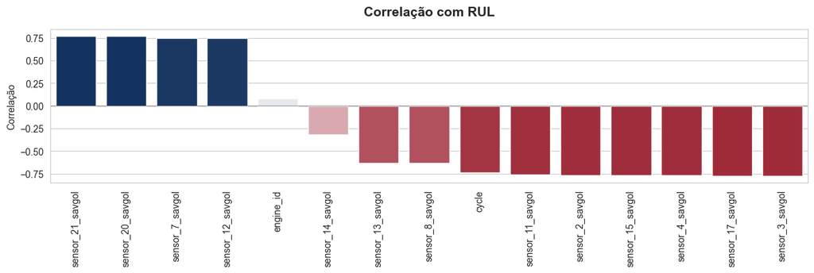

# Model Training

In the next step, the dataset is split into training and testing sets at the engine level to enable proper training of the regression models and unbiased evaluation of their performance. The dataset consists of 100 engines. The training set includes 80 engines, while the test set includes 20 engines.

The training data is further divided into three degradation stages: early, mid, and late, corresponding to the first 30%, the next 40%, and the final 30% of each engine lifecycle, respectively.

The models used include Random Forest Regressor, XGBoost Regressor, LightGBM Regressor, CatBoost Regressor, and Histogram-based Gradient Boosting Regressor. The variables cycle and engine_id are excluded from the set of independent variables to prevent data leakage and ensure that only predictive sensor-based features are used.

# Results Comparison

The following table presents the prediction errors in Remaining Useful Life (RUL) estimation, obtained by evaluating all trained models in two separate experiments: one using the baseline feature set and one using the engineered feature set. The models are ranked according to Late_RMSE in ascending order, as late-stage prediction accuracy is the most operationally relevant criterion for RUL estimation.

|  | Model | RMSE | Early_RMSE | Mid_RMSE | Late_RMSE | MAE | Features |
| --- | --- | --- | --- | --- | --- | --- | --- |
| 0 | HGBRegressor | 38.987999 | 53.315100 | 28.803768 | 6.647421 | 25.078747 | Engineered |
| 1 | LGBMRegressor | 39.370077 | 54.081946 | 28.463356 | 6.697453 | 25.352884 | Engineered |
| 2 | XGBRegressor | 39.085437 | 53.817904 | 27.811844 | 6.700502 | 25.120392 | Engineered |
| 3 | CBRegressor | 40.266947 | 56.103616 | 27.571152 | 6.853846 | 25.941789 | Engineered |
| 4 | RFRegressor | 48.209035 | 63.467405 | 38.536840 | 17.344461 | 33.082135 | Engineered |
| 5 | CBRegressor | 43.310215 | 59.273050 | 30.774656 | 15.768038 | 29.888413 | Baseline |
| 6 | XGBRegressor | 43.782429 | 59.692649 | 31.629974 | 17.116106 | 30.422464 | Baseline |
| 7 | LGBMRegressor | 44.080566 | 60.050631 | 31.930167 | 17.174256 | 30.669344 | Baseline |
| 8 | HGBRegressor | 44.209609 | 60.194413 | 32.168977 | 17.325539 | 30.882475 | Baseline |
| 9 | RFRegressor | 49.265040 | 66.072834 | 37.018623 | 24.513656 | 35.369121 | Baseline |

Improvements in mid-stage prediction are also observed, albeit to a lesser extent, while early-stage prediction remains challenging due to the limited observability of degradation patterns in the initial operational regime. Overall, the results indicate that the engineered feature space enhances the model’s ability to represent degradation progression, especially as the system approaches failure.

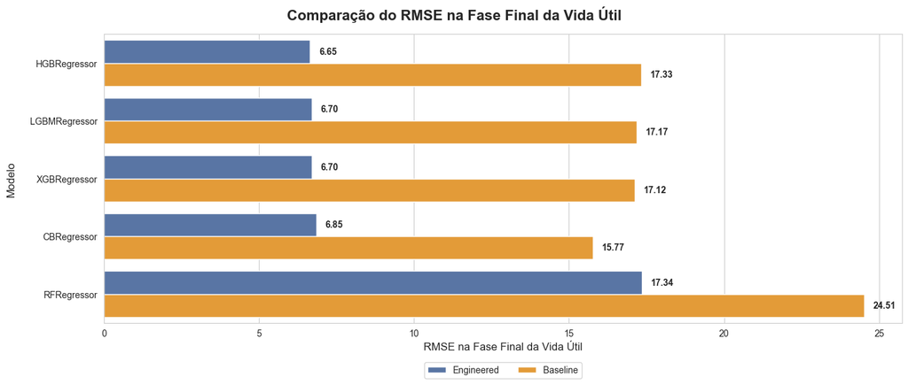

# Discussion

A key finding of this work is the strong effectiveness of Savitzky–Golay (Savgol) filtering as a primary signal transformation. Using a relatively large window size (approximately 50 cycles), the Savgol transformation was able to significantly reduce high-frequency noise while preserving the underlying degradation structure. This resulted in more stable and informative representations of sensor trajectories, particularly in the late degradation phase. In contrast to more complex engineered features, such as rolling statistics, expanding means, and threshold-based deviation indicators, the Savgol-based representation consistently produced superior late-stage RMSE performance. This suggests that, for this dataset, degradation dynamics are better captured through smooth trajectory estimation than through highly parameterized statistical transformations.

The analysis of Sensor 6 further supports the importance of signal structure in feature engineering. This sensor exhibits a highly sparse and discontinuous binary pattern, characterized by long constant regimes interrupted by rare transitions. Unlike the majority of sensors, which show gradual deviation from a healthy operating range followed by accelerating degradation, Sensor 6 does not conform to a continuous degradation assumption. As a result, its contribution to regression models is unstable and potentially misleading, as it introduces structural heterogeneity that is not aligned with the dominant degradation dynamics. This justified its exclusion from the final feature set.

# Conclusion

This study investigated the impact of feature engineering on RUL prediction using the CMAPSS FD001 dataset. The results demonstrate that the most significant performance gains are achieved not through model complexity, but through appropriate transformation of sensor signals into degradation-aware representations.

Among the tested approaches, Savitzky–Golay filtering emerged as the most effective transformation, providing a robust balance between noise reduction and preservation of degradation structure. In contrast, more complex statistical and threshold-based engineered features did not consistently improve predictive performance and were in some cases detrimental when combined with aggressive feature selection techniques.

Overall, the findings suggest that accurate RUL prediction depends more on capturing the structure of degradation trajectories than on increasing feature complexity. The proposed pipeline demonstrates that carefully designed signal smoothing and selective feature engineering can substantially improve late-stage predictive accuracy, which is the most operationally relevant phase for maintenance decision-making.